# Mini assignment 1

Kedar Patil

February 16, 2015

## Comparative Stats for BRIC Countries

### Background

I came across this visual comparing macro economic statistics for BRIC countries on the [Media Research Lab](https://mediaresearchlab.wordpress.com/2012/04/22/infographics-bric-in-comparison/) website. BRIC stands for a group of four countries - Brazil, Russia, India and China, which are all considered at similar stage of economic development. The original visual (reproduced below) seeks to produce a comparative understanding of these countries around 6 factors - Population size, Population growth rate, Unemployment, Inflation, GDP, and Military expenditure.

[figure not shown]

*Fig1: Original visual from Media Research Lab*

### Observations

- *Inconsistant formatting*

  While Brazil and China population numbers are comma saperated, India and Russia are saparated by a dot. Similar thing is observed for percentage values for inflation rates.
- *Visual reresentation is harder to comprehend*

  Even though all numbers are on one visual, the information is siloed, and not readily compared. One has to work a bit to understand comparitive magnitude and standings of each country on metrics that are being presented.
- *Distracting visuals*

  The purpose of human figures represented on country maps is unclear, distracting, and adds to the clutter.

### Scatter plot Matrix & Bar Charts

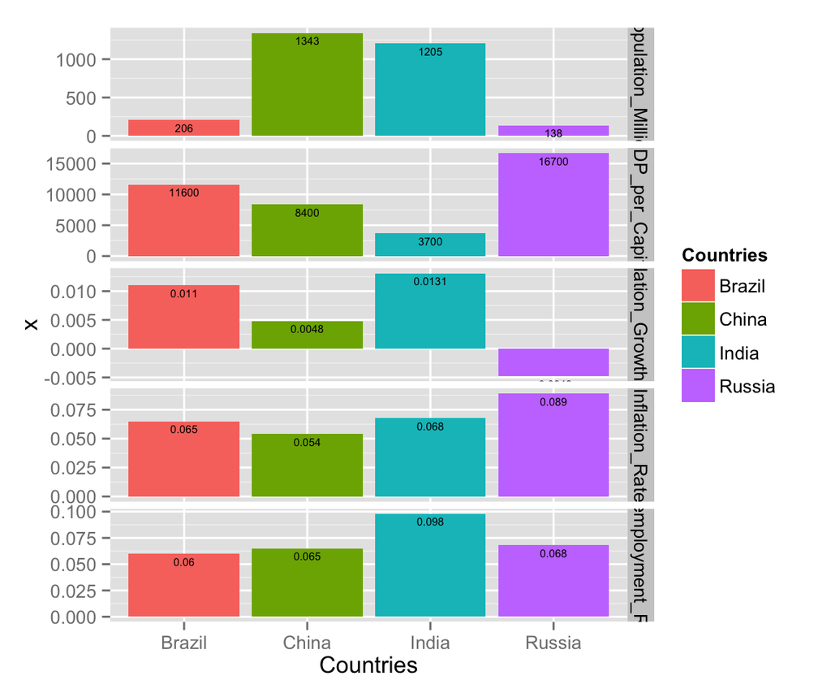

*Fig2: Distribution of variables by Country*

We see that India and China have significantly higher population than Brazil and Russia. Also, Russia has the highest per capita GDP ($16,700), as well as highest inflation rate at 8.9%. It is also the only country with declining population. Brazil and India have highest population growth, little over 1%. India has higest unemployment rate at 9.8%

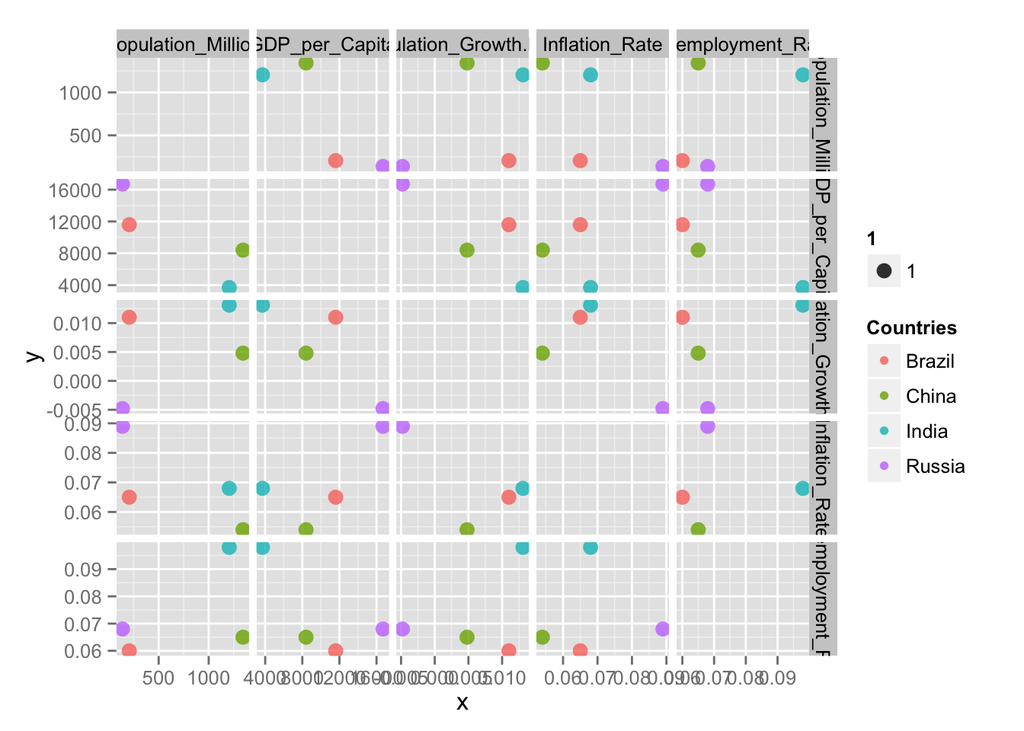

*Fig3: Scatter plot metrix of variables*

Looking at same data on a scatter matrix plot further reveals some similarities between countries.